# ExtraaLearn Project

## Context

The EdTech industry has been surging in the past decade immensely, and according to a forecast, the Online Education market would be worth $286.62bn by 2023 with a compound annual growth rate (CAGR) of 10.26% from 2018 to 2023. The modern era of online education has enforced a lot in its growth and expansion beyond any limit. Due to having many dominant features like ease of information sharing, personalized learning experience, transparency of assessment, etc, it is now preferable to traditional education.

In the present scenario due to the Covid-19, the online education sector has witnessed rapid growth and is attracting a lot of new customers. Due to this rapid growth, many new companies have emerged in this industry. With the availability and ease of use of digital marketing resources, companies can reach out to a wider audience with their offerings. The customers who show interest in these offerings are termed as leads. There are various sources of obtaining leads for Edtech companies, like

- The customer interacts with the marketing front on social media or other online platforms.
- The customer browses the website/app and downloads the brochure
- The customer connects through emails for more information.

The company then nurtures these leads and tries to convert them to paid customers. For this, the representative from the organization connects with the lead on call or through email to share further details.

## Objective

ExtraaLearn is an initial stage startup that offers programs on cutting-edge technologies to students and professionals to help them upskill/reskill. With a large number of leads being generated on a regular basis, one of the issues faced by ExtraaLearn is to identify which of the leads are more likely to convert so that they can allocate resources accordingly. You, as a data scientist at ExtraaLearn, have been provided the leads data to:

- Analyze and build an ML model to help identify which leads are more likely to convert to paid customers,
- Find the factors driving the lead conversion process
- Create a profile of the leads which are likely to convert

## Data Description

The data contains the different attributes of leads and their interaction details with ExtraaLearn. The detailed data dictionary is given below.

**Data Dictionary**

- ID: ID of the lead
- age: Age of the lead
- current_occupation: Current occupation of the lead. Values include 'Professional','Unemployed',and 'Student'
- first_interaction: How did the lead first interacted with ExtraaLearn. Values include 'Website', 'Mobile App'
- profile_completed: What percentage of profile has been filled by the lead on the website/mobile app. Values include Low - (0-50%), Medium - (50-75%), High (75-100%)
- website_visits: How many times has a lead visited the website
- time_spent_on_website: Total time spent on the website
- page_views_per_visit: Average number of pages on the website viewed during the visits.
- last_activity: Last interaction between the lead and ExtraaLearn.
  - Email Activity: Seeking for details about program through email, Representative shared information with lead like brochure of program , etc
  - Phone Activity: Had a Phone Conversation with representative, Had conversation over SMS with representative, etc
  - Website Activity: Interacted on live chat with representative, Updated profile on website, etc
- print_media_type1: Flag indicating whether the lead had seen the ad of ExtraaLearn in the Newspaper.
- print_media_type2: Flag indicating whether the lead had seen the ad of ExtraaLearn in the Magazine.
- digital_media: Flag indicating whether the lead had seen the ad of ExtraaLearn on the digital platforms.
- educational_channels: Flag indicating whether the lead had heard about ExtraaLearn in the education channels like online forums, discussion threads, educational websites, etc.
- referral: Flag indicating whether the lead had heard about ExtraaLearn through reference.
- status: Flag indicating whether the lead was converted to a paid customer or not.

## Importing necessary libraries and data

```python
# Importing the basic libraries we will require for the project

# Libraries to help with reading and manipulating data
import pandas as pd
import numpy as np

# Libaries to help with data visualization
import matplotlib.pyplot as plt
import seaborn as sns
sns.set()

# Importing the Machine Learning models we require from Scikit-Learn
from sklearn.linear_model import LogisticRegression
from sklearn.svm import SVC
from sklearn.tree import DecisionTreeClassifier
from sklearn import tree
from sklearn.ensemble import RandomForestClassifier

# Importing the other functions we may require from Scikit-Learn
from sklearn.model_selection import train_test_split, GridSearchCV
from sklearn.preprocessing import StandardScaler
from sklearn.preprocessing import MinMaxScaler, LabelEncoder, OneHotEncoder
from sklearn.impute import SimpleImputer


# Metrics to evaluate the model
from sklearn import metrics
from sklearn.metrics import confusion_matrix, classification_report, precision_recall_curve,recall_score
from sklearn import tree

# For tuning the model
from sklearn.model_selection import GridSearchCV

# Code to ignore warnings from function usage
import warnings;
import numpy as np
warnings.filterwarnings('ignore')
```

```python
from google.colab import drive
drive.mount('/content/drive')
```

```python
#Load the data file
data = pd.read_csv("/content/drive/MyDrive/MIT - week 8/Project 2 for submission/ExtraaLearn.csv")

# Copying data to another variable to avoid any changes to the original data
df = data.copy()
```

## Data Overview

- Observations
- Sanity checks

```python
# returning the first 5 rows
df.head()
```

|  | ID | age | current_occupation | first_interaction | profile_completed | website_visits | time_spent_on_website | page_views_per_visit | last_activity | print_media_type1 | print_media_type2 | digital_media | educational_channels | referral | status |
| --- | --- | --- | --- | --- | --- | --- | --- | --- | --- | --- | --- | --- | --- | --- | --- |
| 0 | EXT001 | 57 | Unemployed | Website | High | 7 | 1639 | 1.861 | Website Activity | Yes | No | Yes | No | No | 1 |
| 1 | EXT002 | 56 | Professional | Mobile App | Medium | 2 | 83 | 0.320 | Website Activity | No | No | No | Yes | No | 0 |
| 2 | EXT003 | 52 | Professional | Website | Medium | 3 | 330 | 0.074 | Website Activity | No | No | Yes | No | No | 0 |
| 3 | EXT004 | 53 | Unemployed | Website | High | 4 | 464 | 2.057 | Website Activity | No | No | No | No | No | 1 |
| 4 | EXT005 | 23 | Student | Website | High | 4 | 600 | 16.914 | Email Activity | No | No | No | No | No | 0 |

```python
# returning the last 5 rows
df.tail()
```

|  | ID | age | current_occupation | first_interaction | profile_completed | website_visits | time_spent_on_website | page_views_per_visit | last_activity | print_media_type1 | print_media_type2 | digital_media | educational_channels | referral | status |
| --- | --- | --- | --- | --- | --- | --- | --- | --- | --- | --- | --- | --- | --- | --- | --- |
| 4607 | EXT4608 | 35 | Unemployed | Mobile App | Medium | 15 | 360 | 2.170 | Phone Activity | No | No | No | Yes | No | 0 |
| 4608 | EXT4609 | 55 | Professional | Mobile App | Medium | 8 | 2327 | 5.393 | Email Activity | No | No | No | No | No | 0 |
| 4609 | EXT4610 | 58 | Professional | Website | High | 2 | 212 | 2.692 | Email Activity | No | No | No | No | No | 1 |
| 4610 | EXT4611 | 57 | Professional | Mobile App | Medium | 1 | 154 | 3.879 | Website Activity | Yes | No | No | No | No | 0 |
| 4611 | EXT4612 | 55 | Professional | Website | Medium | 4 | 2290 | 2.075 | Phone Activity | No | No | No | No | No | 0 |

```python
df.shape
```

```
(4612, 15)
```

#### Observations:

There are 4612 rows and 15 columns present in the data.

```python
df.info()
```

```
<class 'pandas.core.frame.DataFrame'>
RangeIndex: 4612 entries, 0 to 4611
Data columns (total 15 columns):
 #   Column                 Non-Null Count  Dtype
---  ------                 --------------  -----
 0   ID                     4612 non-null   object
 1   age                    4612 non-null   int64
 2   current_occupation     4612 non-null   object
 3   first_interaction      4612 non-null   object
 4   profile_completed      4612 non-null   object
 5   website_visits         4612 non-null   int64
 6   time_spent_on_website  4612 non-null   int64
 7   page_views_per_visit   4612 non-null   float64
 8   last_activity          4612 non-null   object
 9   print_media_type1      4612 non-null   object
 10  print_media_type2      4612 non-null   object
 11  digital_media          4612 non-null   object
 12  educational_channels   4612 non-null   object
 13  referral               4612 non-null   object
 14  status                 4612 non-null   int64
dtypes: float64(1), int64(4), object(10)
memory usage: 540.6+ KB
```

#### Observations:

There are integer, float, and categorical data. There is no missing data.

```python
# Checking unique values in each column
df.nunique()
```

```
ID                       4612
age                        46
current_occupation          3
first_interaction           2
profile_completed           3
website_visits             27
time_spent_on_website    1623
page_views_per_visit     2414
last_activity               3
print_media_type1           2
print_media_type2           2
digital_media               2
educational_channels        2
referral                    2
status                      2
dtype: int64
```

#### Observations:

Every column has more than one unique value, and may be useful in building the model. However, the ID number is irrelevant and so we will drop that column.

```python
#Checking for duplicates
print(data.duplicated().sum())
print(df.duplicated().sum())
```

```
0
0
```

#### Observations:

There are no duplicate entries in the original dataset. There are some leads that coincidentally have identical data, but these are still unique entries.

```python
# Dropping the columns
df=df.drop(['ID'],axis=1)
```

```python
# Numerical data set
num_data = ['age', 'website_visits', 'time_spent_on_website', 'page_views_per_visit']

#Categorical data set
cat_data = ['current_occupation', 'first_interaction', 'profile_completed', 'last_activity',
            'print_media_type1', 'print_media_type2', 'digital_media', 'educational_channels', 'referral', 'status' ]
```

## Exploratory Data Analysis (EDA)

- EDA is an important part of any project involving data.
- It is important to investigate and understand the data better before building a model with it.
- A few questions have been mentioned below which will help you approach the analysis in the right manner and generate insights from the data.
- A thorough analysis of the data, in addition to the questions mentioned below, should be done.

**Questions**

1. Leads will have different expectations from the outcome of the course and the current occupation may play a key role in getting them to participate in the program. Find out how current occupation affects lead status.
2. The company's first impression on the customer must have an impact. Do the first channels of interaction have an impact on the lead status?
3. The company uses multiple modes to interact with prospects. Which way of interaction works best?
4. The company gets leads from various channels such as print media, digital media, referrals, etc. Which of these channels have the highest lead conversion rate?
5. People browsing the website or mobile application are generally required to create a profile by sharing their personal data before they can access additional information.Does having more details about a prospect increase the chances of conversion?

#### Univariate analysis of numerical data

```python
# Checking summary statistics
df[num_data].describe().T
```

|  | count | mean | std | min | 25% | 50% | 75% | max |
| --- | --- | --- | --- | --- | --- | --- | --- | --- |
| age | 4612.0 | 46.201214 | 13.161454 | 18.0 | 36.00000 | 51.000 | 57.00000 | 63.000 |
| website_visits | 4612.0 | 3.566782 | 2.829134 | 0.0 | 2.00000 | 3.000 | 5.00000 | 30.000 |
| time_spent_on_website | 4612.0 | 724.011275 | 743.828683 | 0.0 | 148.75000 | 376.000 | 1336.75000 | 2537.000 |
| page_views_per_visit | 4612.0 | 3.026126 | 1.968125 | 0.0 | 2.07775 | 2.792 | 3.75625 | 18.434 |

#### Observations:

- The age data includes both young and older adults between the ages of 18-63 years.
- The average number of website visits is 3.6.
- The total time spent on the website averages at 724, with a median of 376.  
  *The number of page visits averages at ~3.0. There is at least one outlier at the maximum value of 18.4 average page views per visit.

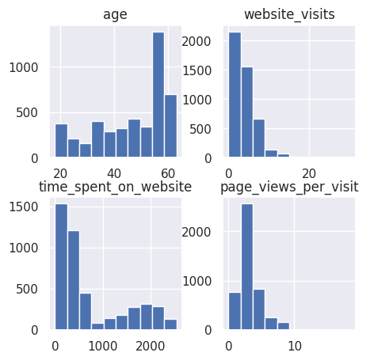

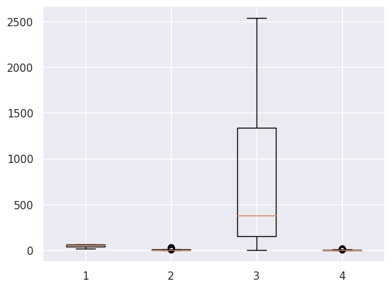

```python
# Creating histograms
df[num_data].hist(figsize=(5,5))
plt.show()

plt.boxplot(df[num_data])
plt.show()
```

#### Observations:

-The number of website visits and the average time spent on the website data are skewed to the right, whereas the age data is skewed left

-The page views per visit is approximately normally distribtuted

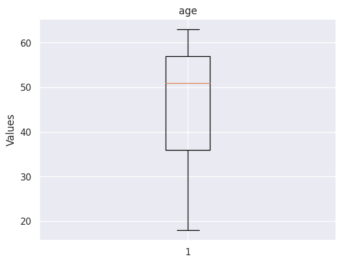

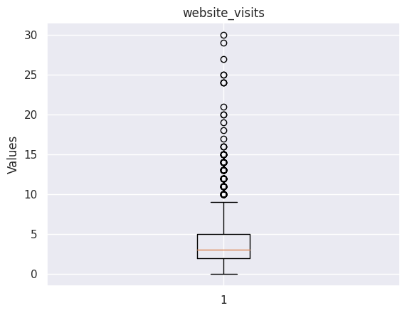

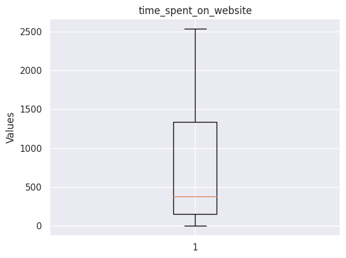

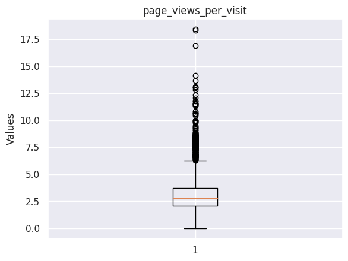

```python
#Creating boxplots
for x in num_data:
    plt.figure()
    plt.boxplot(df[x])
    plt.title(x)
    plt.ylabel('Values')
    plt.show()
```

#### Observations:

The number of wesbite visits and the average number of pages viewed per visit both have outliers at higher values.

#### Univariate analysis of categorical data

```python
# Printing the % sub categories of each category
for x in cat_data:
    print(df[x].value_counts(normalize=True))
    print('*'*40)
```

```
Professional    0.567216
Unemployed      0.312446
Student         0.120338
Name: current_occupation, dtype: float64
Website       0.551171
Mobile App    0.448829
Name: first_interaction, dtype: float64
High      0.490893
Medium    0.485906
Low       0.023200
Name: profile_completed, dtype: float64
Email Activity      0.493929
Phone Activity      0.267563
Website Activity    0.238508
Name: last_activity, dtype: float64
No     0.892238
Yes    0.107762
Name: print_media_type1, dtype: float64
No     0.94948
Yes    0.05052
Name: print_media_type2, dtype: float64
No     0.885733
Yes    0.114267
Name: digital_media, dtype: float64
No     0.847138
Yes    0.152862
Name: educational_channels, dtype: float64
No     0.979835
Yes    0.020165
Name: referral, dtype: float64
0    0.701431
1    0.298569
Name: status, dtype: float64
```

#### Bivariate and Multivariate Analysis

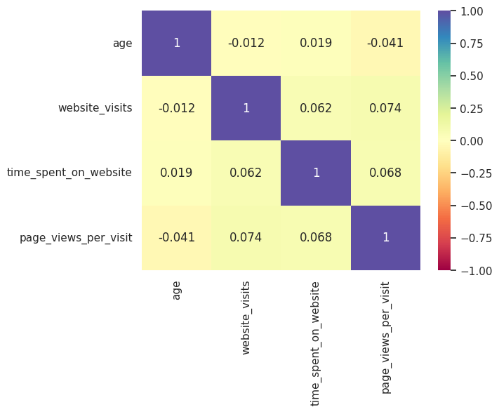

```python
#Creating correlation heatmap for numerical data
sns.heatmap(df[num_data].corr(),annot=True,cmap='Spectral',vmin=-1,vmax=1);
plt.show();
```

#### Observations:

- None of the numerical data is correlated with eachother

```python
# how current occupation affects lead status
print(pd.crosstab(df['status'],df['current_occupation']))
print('*'*20)
print(df['current_occupation'].value_counts())
```

```
current_occupation  Professional  Student  Unemployed
status
0                           1687      490        1058
1                            929       65         383
Professional    2616
Unemployed      1441
Student          555
Name: current_occupation, dtype: int64
```

#### Observations:

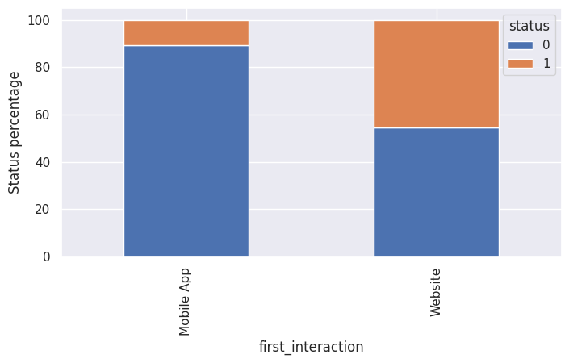

```python
#Relating channel of first interaction to status
(pd.crosstab(df['first_interaction'],df['status'],normalize='index')*100).plot(kind='bar',figsize=(8,4),stacked=True, )
plt.ylabel('Status percentage')
```

#### Observations:

Roughly 50% of those whose first interaction was on the website were converted to customers, whereas only roughly 10% of those whose first interaction was on the mobile app were converted to customers.

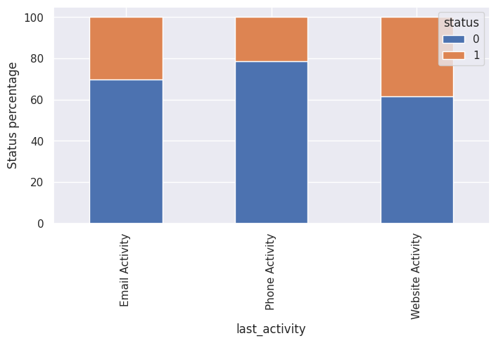

```python
#Relating last interaction with status
(pd.crosstab(df['last_activity'],df['status'],normalize='index')*100).plot(kind='bar',figsize=(8,4),stacked=True, )
plt.ylabel('Status percentage')
```

#### Observations:

According to the chart, the highest percantage of converted customers occured when the lead's last activity was on the website.

```python
data.info()
```

```
<class 'pandas.core.frame.DataFrame'>
RangeIndex: 4612 entries, 0 to 4611
Data columns (total 15 columns):
 #   Column                 Non-Null Count  Dtype
---  ------                 --------------  -----
 0   ID                     4612 non-null   object
 1   age                    4612 non-null   int64
 2   current_occupation     4612 non-null   object
 3   first_interaction      4612 non-null   object
 4   profile_completed      4612 non-null   object
 5   website_visits         4612 non-null   int64
 6   time_spent_on_website  4612 non-null   int64
 7   page_views_per_visit   4612 non-null   float64
 8   last_activity          4612 non-null   object
 9   print_media_type1      4612 non-null   object
 10  print_media_type2      4612 non-null   object
 11  digital_media          4612 non-null   object
 12  educational_channels   4612 non-null   object
 13  referral               4612 non-null   object
 14  status                 4612 non-null   int64
dtypes: float64(1), int64(4), object(10)
memory usage: 540.6+ KB
```

```python
#Determining which channel has the highest lead conversion rate
channels = ['print_media_type1', 'print_media_type2', 'digital_media', 'educational_channels', 'referral']
for x in channels:
  channel_conversion_rates = pd.crosstab(df[x], df['status'])
  print(channel_conversion_rates)
  print(df[x].value_counts())
  print('*'*30)
```

```
status                0     1
print_media_type1
No                 2897  1218
Yes                 338   159
No     4115
Yes     497
Name: print_media_type1, dtype: int64
status                0     1
print_media_type2
No                 3077  1302
Yes                 158    75
No     4379
Yes     233
Name: print_media_type2, dtype: int64
status            0     1
digital_media
No             2876  1209
Yes             359   168
No     4085
Yes     527
Name: digital_media, dtype: int64
status                   0     1
educational_channels
No                    2727  1180
Yes                    508   197
No     3907
Yes     705
Name: educational_channels, dtype: int64
status       0     1
referral
No        3205  1314
Yes         30    63
No     4519
Yes      93
Name: referral, dtype: int64
```

#### Observations:

The conversion rates were as follows:

- print_media_type1, 159/497 or 32%
- print_media_type2, 75/233 or 32%
- digital_media, 168/527 or 32%
- educational_channels, 197/705 or 28%
- referral, 63/93 or 68%

Overall, the referral channel has the highest lead conversion rate of 68%

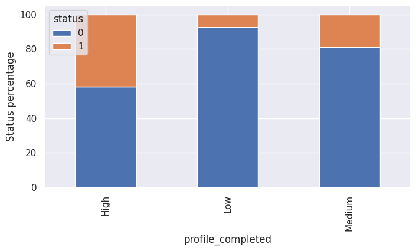

```python
#Examining relationships between percentage of profile created and conversion rate
(pd.crosstab(df['profile_completed'],df['status'],normalize='index')*100).plot(kind='bar',figsize=(8,4),stacked=True, );
plt.ylabel('Status percentage');
```

As observed in the graph, the higher the percentage of profile completed, the higher the conversion rate.

## Data Preprocessing

- Missing value treatment (if needed)
- Feature engineering (if needed)
- Outlier detection and treatment (if needed)
- Preparing data for modeling
- Any other preprocessing steps (if needed)

```python
# Creating dummy variables for categorical variables

# Creating list of dummy columns
to_get_dummies_for = ['current_occupation', 'first_interaction', 'profile_completed', 'last_activity', 'print_media_type1', 'print_media_type2', 'digital_media', 'educational_channels', 'referral']

# Creating dummy variables
df = pd.get_dummies(data = df, columns = to_get_dummies_for, drop_first = True)

# Mapping yes/no columns
dict_print_media_type1 = {'Yes': 1, 'No':0}
dict_print_media_type2 = {'Yes': 1, 'No':0}
dict_digital_media = {'Yes': 1, 'No':0}
dict_educational_channels = {'Yes': 1, 'No':0}
dict_referral = {'Yes': 1, 'No':0}

df['print_media_type1'] = df.print_media_type1.map(dict_print_media_type1)
df['print_media_type2'] = df.print_media_type2.map(dict_print_media_type2)
df['digital_media'] = df.digital_media.map(dict_digital_media)
df['educational_channels'] = df.educational_channels.map(dict_educational_channels)
df['referral'] = df.referral.map(dict_referral)
```

```python
#Separating the independent variables (X) and the dependent variable (Y)

Y= df.status
X= df.drop(columns = ['status'])
```

```python
# Splitting the data
X_train, X_test, y_train, y_test = train_test_split(X, Y, test_size = 0.3, random_state = 1, stratify = Y)
```

```python
# Create a function to calculate and print the classification report and confusion matrix
def metrics_score(actual, predicted):
    print(classification_report(actual, predicted))

    cm = confusion_matrix(actual, predicted)
    plt.figure(figsize=(8,5))

    sns.heatmap(cm, annot=True,  fmt='.2f', xticklabels=['Converted', 'Not converted'], yticklabels=['Converted', 'Not converted'])
    plt.ylabel('Actual')
    plt.xlabel('Predicted')
    plt.show()
```

## EDA

- It is a good idea to explore the data once again after manipulating it.

```python
df.head()
```

|  | age | website_visits | time_spent_on_website | page_views_per_visit | status | current_occupation_Student | current_occupation_Unemployed | first_interaction_Website | profile_completed_Low | profile_completed_Medium | last_activity_Phone Activity | last_activity_Website Activity | print_media_type1_Yes | print_media_type2_Yes | digital_media_Yes | educational_channels_Yes | referral_Yes |
| --- | --- | --- | --- | --- | --- | --- | --- | --- | --- | --- | --- | --- | --- | --- | --- | --- | --- |
| 0 | 57 | 7 | 1639 | 1.861 | 1 | 0 | 1 | 1 | 0 | 0 | 0 | 1 | 1 | 0 | 1 | 0 | 0 |
| 1 | 56 | 2 | 83 | 0.320 | 0 | 0 | 0 | 0 | 0 | 1 | 0 | 1 | 0 | 0 | 0 | 1 | 0 |
| 2 | 52 | 3 | 330 | 0.074 | 0 | 0 | 0 | 1 | 0 | 1 | 0 | 1 | 0 | 0 | 1 | 0 | 0 |
| 3 | 53 | 4 | 464 | 2.057 | 1 | 0 | 1 | 1 | 0 | 0 | 0 | 1 | 0 | 0 | 0 | 0 | 0 |
| 4 | 23 | 4 | 600 | 16.914 | 0 | 1 | 0 | 1 | 0 | 0 | 0 | 0 | 0 | 0 | 0 | 0 | 0 |

```python
df.info()
```

```
<class 'pandas.core.frame.DataFrame'>
RangeIndex: 4612 entries, 0 to 4611
Data columns (total 17 columns):
 #   Column                          Non-Null Count  Dtype
---  ------                          --------------  -----
 0   age                             4612 non-null   int64
 1   website_visits                  4612 non-null   int64
 2   time_spent_on_website           4612 non-null   int64
 3   page_views_per_visit            4612 non-null   float64
 4   status                          4612 non-null   int64
 5   current_occupation_Student      4612 non-null   uint8
 6   current_occupation_Unemployed   4612 non-null   uint8
 7   first_interaction_Website       4612 non-null   uint8
 8   profile_completed_Low           4612 non-null   uint8
 9   profile_completed_Medium        4612 non-null   uint8
 10  last_activity_Phone Activity    4612 non-null   uint8
 11  last_activity_Website Activity  4612 non-null   uint8
 12  print_media_type1_Yes           4612 non-null   uint8
 13  print_media_type2_Yes           4612 non-null   uint8
 14  digital_media_Yes               4612 non-null   uint8
 15  educational_channels_Yes        4612 non-null   uint8
 16  referral_Yes                    4612 non-null   uint8
dtypes: float64(1), int64(4), uint8(12)
memory usage: 234.3 KB
```

## Building a Decision Tree model

```python
# Building decision tree model
dt = DecisionTreeClassifier(class_weight = {0: 0.17, 1: 0.83}, random_state = 1)
```

```python
# Fitting decision tree model
dt.fit(X_train, y_train)
```

```
DecisionTreeClassifier(class_weight={0: 0.17, 1: 0.83}, random_state=1)
```

```
              precision    recall  f1-score   support

           0       1.00      1.00      1.00      2264
           1       1.00      1.00      1.00       964

    accuracy                           1.00      3228
   macro avg       1.00      1.00      1.00      3228
weighted avg       1.00      1.00      1.00      3228
```

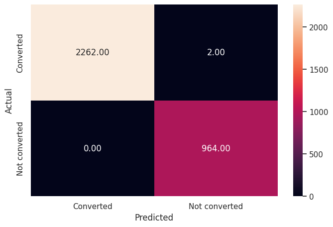

```python
# Checking performance on the training dataset
y_train_pred_dt = dt.predict(X_train)

metrics_score(y_train, y_train_pred_dt)
```

Observation: The score is 100% for precision, recall, and F1.

```
              precision    recall  f1-score   support

           0       0.85      0.85      0.85       971
           1       0.65      0.64      0.65       413

    accuracy                           0.79      1384
   macro avg       0.75      0.75      0.75      1384
weighted avg       0.79      0.79      0.79      1384
```

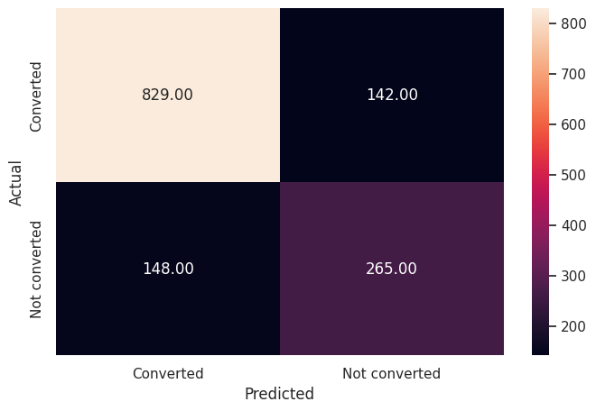

```python
# Checking performance on the test dataset
y_test_pred_dt = dt.predict(X_test)

metrics_score(y_test, y_test_pred_dt)
```

Observations:

- The precision, recall, and F1 scores have decreased, which suggests that the model was overfitting the training dataset.

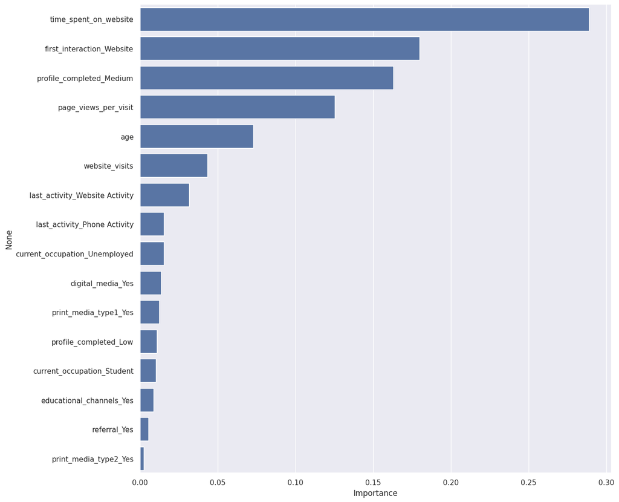

```python
# Plot the feature importance

importances = dt.feature_importances_
columns = X.columns
importance_df = pd.DataFrame(importances, index=columns, columns=['Importance']).sort_values(by='Importance', ascending=False)

plt.figure(figsize=(13, 13))
sns.barplot(x=importance_df.Importance, y=importance_df.index)
plt.show()
```

Observations: The most important feature is time spent on website, followed by the first interaction, specifically if the interaction was on the website. Also of importance are the percentage of profile completed and the average number of page views per visit.

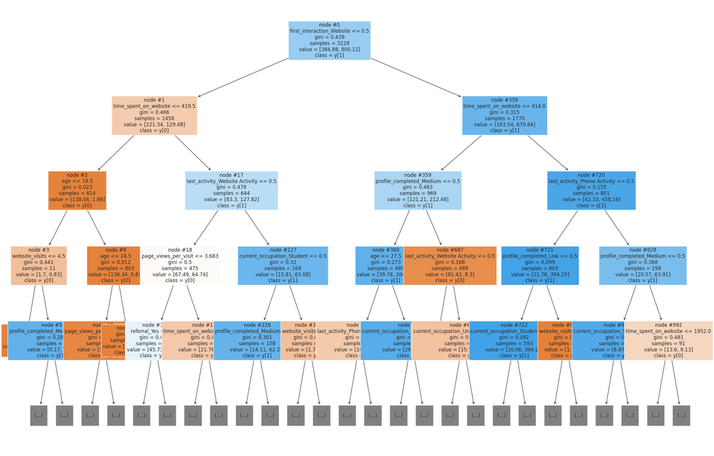

```python
#Plotting the decision tree
features = list(X.columns)

plt.figure(figsize = (30, 20))

tree.plot_tree(dt, max_depth = 4, feature_names = features, filled = True, fontsize = 12, node_ids = True, class_names = True)

plt.show()
```

## Do we need to prune the tree?

It would be beneficial to prune the tree, as pruning would reduce the overfitting problem on the training data set.

```python
#Hyperparameter tuning for decision tree

# Choose the type of classifier
dtree_estimator = DecisionTreeClassifier(class_weight = {0: 0.17, 1: 0.83}, random_state = 1)

# Grid of parameters to choose from
parameters = {'max_depth': np.arange(2, 7),
              'criterion': ['gini', 'entropy'],
              'min_samples_leaf': [5, 10, 20, 25]
             }

# Type of scoring used to compare parameter combinations
scorer = metrics.make_scorer(recall_score, pos_label = 1)

# Run the grid search
gridCV = GridSearchCV(dtree_estimator, parameters, scoring = scorer, cv = 10)

# Fitting the grid search on the train data
gridCV = gridCV.fit(X_train, y_train)

# Set the classifier to the best combination of parameters
dtree_estimator = gridCV.best_estimator_

# Fit the best estimator to the data
dtree_estimator.fit(X_train, y_train)
```

```
DecisionTreeClassifier(class_weight={0: 0.17, 1: 0.83}, max_depth=2,
                       min_samples_leaf=5, random_state=1)
```

```
              precision    recall  f1-score   support

           0       1.00      0.36      0.53      2264
           1       0.40      1.00      0.57       964

    accuracy                           0.55      3228
   macro avg       0.70      0.68      0.55      3228
weighted avg       0.82      0.55      0.54      3228
```

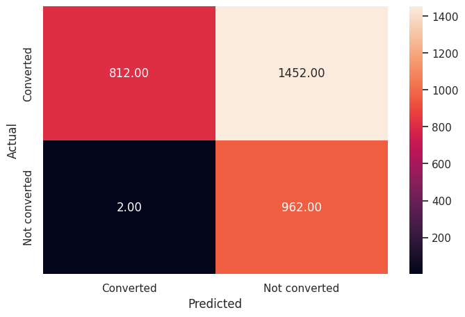

```python
# Checking performance on the training dataset
y_train_pred_dt = dtree_estimator.predict(X_train)

metrics_score(y_train, y_train_pred_dt)
```

Observations: The performance on the training set has gone down compared to the original decision tree model.

```
              precision    recall  f1-score   support

           0       0.99      0.34      0.50       971
           1       0.39      0.99      0.56       413

    accuracy                           0.53      1384
   macro avg       0.69      0.66      0.53      1384
weighted avg       0.81      0.53      0.52      1384
```

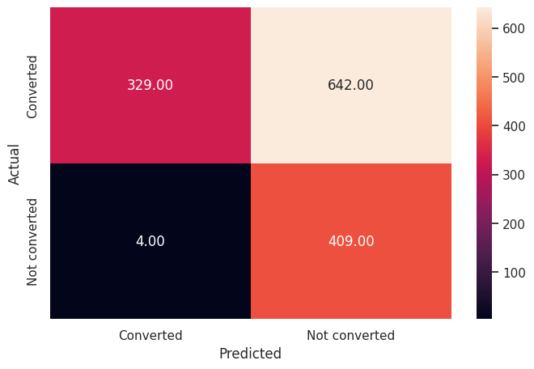

```python
# Checking performance on the test dataset
y_test_pred_dt = dtree_estimator.predict(X_test)

metrics_score(y_test, y_test_pred_dt)
```

Observations: The model is not tuned well on the test data set either.

## Building a Random Forest model

```python
# Fitting the Random Forest classifier on the training data
rf_estimator = RandomForestClassifier(class_weight = {0: 0.17, 1: 0.83}, random_state = 1)

rf_estimator.fit(X_train, y_train)
```

```
RandomForestClassifier(class_weight={0: 0.17, 1: 0.83}, random_state=1)
```

```
              precision    recall  f1-score   support

           0       1.00      1.00      1.00      2264
           1       1.00      1.00      1.00       964

    accuracy                           1.00      3228
   macro avg       1.00      1.00      1.00      3228
weighted avg       1.00      1.00      1.00      3228
```

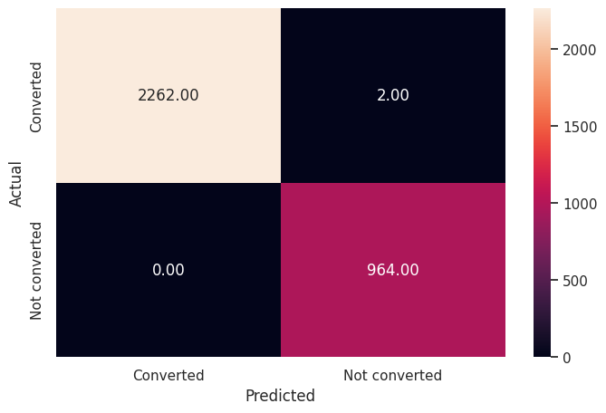

```python
# Checking performance on the training data
y_pred_train_rf = rf_estimator.predict(X_train)

metrics_score(y_train, y_pred_train_rf)
```

Observation: The score is 100% for precision, recall, and F1.

```
              precision    recall  f1-score   support

           0       0.88      0.92      0.90       971
           1       0.79      0.70      0.74       413

    accuracy                           0.86      1384
   macro avg       0.84      0.81      0.82      1384
weighted avg       0.85      0.86      0.85      1384
```

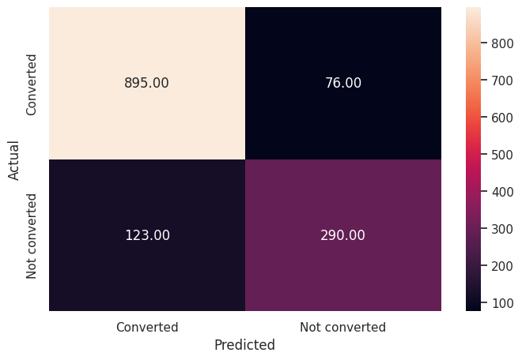

```python
# Checking performance on the testing data
y_pred_test_rf = rf_estimator.predict(X_test)

metrics_score(y_test, y_pred_test_rf)
```

Observations:

- The precision, recall, and F1 scores have decreased, which suggests that the model was overfitting the training dataset. However, the scores in the random forest are an improvement over the scores in the decision tree method.

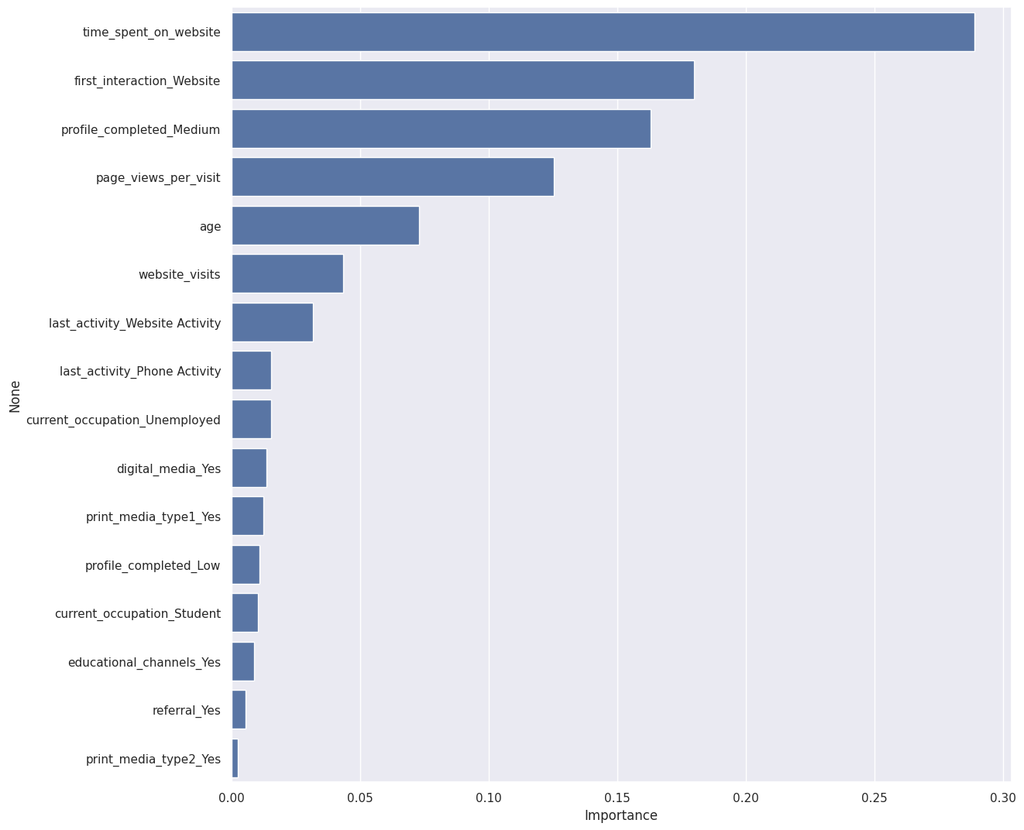

```python
# Plot the feature importance

importances = dt.feature_importances_
columns = X.columns
importance_df = pd.DataFrame(importances, index=columns, columns=['Importance']).sort_values(by='Importance', ascending=False)

plt.figure(figsize=(13, 13))
sns.barplot(x=importance_df.Importance, y=importance_df.index)
plt.show()
```

## Do we need to prune the tree?

It would be beneficial to prune the tree, as pruning would reduce the overfitting problem on the training data set.

```python
#Tuning the model
# Choose the type of classifier
rf_estimator_tuned = RandomForestClassifier(class_weight = {0: 0.17, 1: 0.83}, random_state = 1)

# Grid of parameters to choose from
params_rf = {
        "n_estimators": [100, 250, 500],
        "min_samples_leaf": np.arange(1, 4, 1),
        "max_features": [0.7, 0.9, 'auto'],
}


# Type of scoring used to compare parameter combinations - recall score for class 1
scorer = metrics.make_scorer(recall_score, pos_label = 1)

# Run the grid search
grid_obj = GridSearchCV(rf_estimator_tuned, params_rf, scoring = scorer, cv = 5)

grid_obj = grid_obj.fit(X_train, y_train)

# Set the classifier to the best combination of parameters
rf_estimator_tuned = grid_obj.best_estimator_
```

```python
rf_estimator_tuned.fit(X_train, y_train)
```

```
RandomForestClassifier(class_weight={0: 0.17, 1: 0.83}, max_features='auto',
                       min_samples_leaf=3, random_state=1)
```

```
              precision    recall  f1-score   support

           0       1.00      0.89      0.94      2264
           1       0.79      0.99      0.88       964

    accuracy                           0.92      3228
   macro avg       0.89      0.94      0.91      3228
weighted avg       0.93      0.92      0.92      3228
```

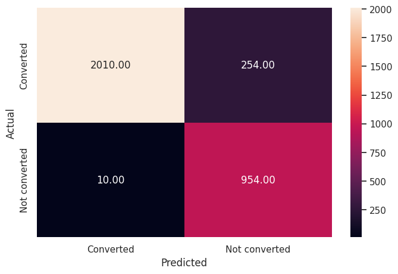

```python
# Checking performance on the training data
y_pred_train_rf_tuned = rf_estimator_tuned.predict(X_train)

metrics_score(y_train, y_pred_train_rf_tuned)
```

Observation: The score is good to high for precision, recall, and F1.

```
              precision    recall  f1-score   support

           0       0.92      0.84      0.87       971
           1       0.68      0.82      0.74       413

    accuracy                           0.83      1384
   macro avg       0.80      0.83      0.81      1384
weighted avg       0.85      0.83      0.83      1384
```

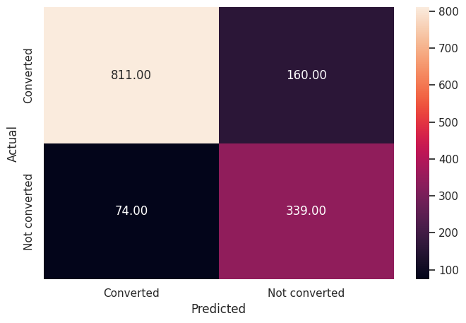

```python
# Checking performance on the test data
y_pred_test_rf_tuned = rf_estimator_tuned.predict(X_test)

metrics_score(y_test, y_pred_test_rf_tuned)
```

Observations: The scores are still pretty good, indicating that the overfitting problem has been at least partially resolved.

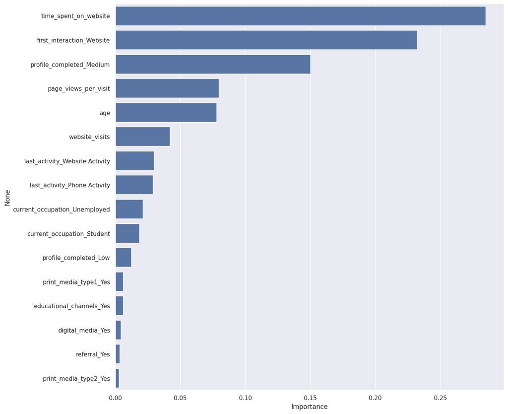

```python
# Plotting feature importance
importances = rf_estimator_tuned.feature_importances_

columns = X.columns

importance_df = pd.DataFrame(importances, index = columns, columns = ['Importance']).sort_values(by = 'Importance', ascending = False)

plt.figure(figsize = (13, 13))

sns.barplot(x=importance_df.Importance, y=importance_df.index)
plt.show()
```

Observations: The important features are similar to the ones as observed in previous models.

## Actionable Insights and Recommendations

- The random forest algorithm gave better scores overall for the model compared to the decision tree model. Hyperparameter tuning helped to reduce overfitting.
- With both the decision tree and random forest, two important features were the time spent on the website, and the average page views per visit. ExtraLearn should spend time developing its website to increase the time potential customers spend browsing through their webpages as well as increase the number of page views
- Encouraging potential customers to complete some of their profile may help in conbverting more leads